# Lec-27: Sentiment Analysis (part 2)

Published

October 30, 2024

```r
# packages
library(tidyverse)    # base tidy data tools
library(tidytext)     # text mining; gets along with tidyverse
library(janeaustenr)  # Jane Austen's novels
```

# 1 Introduction

This is a companion file to the lecture on “Sentiment Analysis (part 2)”.

The code and examples are adapted from the book **Text Mining with R: A Tidy Approach** by Julia Silge and David Robinson.

https://www.tidytextmining.com/

## 1.1 Jane Austen’s Novels

The package `"janeaustenr"` contains the text of six novels written by English writer Jane Austen:

- Sense and Sensibility
- Pride and Prejudice
- Mansfield Park
- Emma
- Northanger Abbey
- Persuasion

All of Jane Austen’s novels, are available in the tibble returned by `austen_books()`:

```r
austen_books() |>
  slice_head(n = 10)
```

```
# A tibble: 10 × 2
   text                    book
   <chr>                   <fct>
 1 "SENSE AND SENSIBILITY" Sense & Sensibility
 2 ""                      Sense & Sensibility
 3 "by Jane Austen"        Sense & Sensibility
 4 ""                      Sense & Sensibility
 5 "(1811)"                Sense & Sensibility
 6 ""                      Sense & Sensibility
 7 ""                      Sense & Sensibility
 8 ""                      Sense & Sensibility
 9 ""                      Sense & Sensibility
10 "CHAPTER 1"             Sense & Sensibility
```

```r
# which books:
austen_books() |>
  distinct(book)
```

```
# A tibble: 6 × 1
  book
  <fct>
1 Sense & Sensibility
2 Pride & Prejudice
3 Mansfield Park
4 Emma
5 Northanger Abbey
6 Persuasion
```

# 2 More Sentiment Analysis

We can use the tools of text mining to approach the emotional content of text. One way to analyze the sentiment of a text is to consider the text as a combination of its individual words, and the sentiment of the whole text as the sum of the sentiment content of the individual words.

This isn’t the only way to approach sentiment analysis, but it is the most common one.

The `"tidytext"` package comes with the `sentiments` dataset that contains a dictionary or **lexicon** (curated by Bing Liu) of words and their associated sentiment.

```r
rbind(head(sentiments, 5), tail(sentiments, 5))
```

```
# A tibble: 10 × 2
   word       sentiment
   <chr>      <chr>
 1 2-faces    negative
 2 abnormal   negative
 3 abolish    negative
 4 abominable negative
 5 abominably negative
 6 zealously  negative
 7 zenith     positive
 8 zest       positive
 9 zippy      positive
10 zombie     negative
```

## 2.1 Change of sentiments throughout each novel

Instead of focusing on a single novel, we can take into account all novels and inspect the “flow” of sentiments along their texts.

For convenience purpose, we will add (`mutate`) two auxiliary columns:

- `linenumber`
- `chapter`

After that, we tokenize with `unnest_tokens()`, and then proceed to remove stop-words:

```r
austen_tokens <- austen_books() |>
  group_by(book) |>
  mutate(
    linenumber = row_number(),
    chapter = cumsum(
      str_detect(text, regex("^chapter [\\divxlc]", ignore_case = TRUE)))) |>
  ungroup() |>
  unnest_tokens(word, text) |>
  anti_join(stop_words, by = "word")

head(austen_tokens)
```

```
# A tibble: 6 × 4
  book                linenumber chapter word
  <fct>                    <int>   <int> <chr>
1 Sense & Sensibility          1       0 sense
2 Sense & Sensibility          1       0 sensibility
3 Sense & Sensibility          3       0 jane
4 Sense & Sensibility          3       0 austen
5 Sense & Sensibility          5       0 1811
6 Sense & Sensibility         10       1 chapter
```

```r
tail(austen_tokens)
```

```
# A tibble: 6 × 4
  book       linenumber chapter word
  <fct>           <int>   <int> <chr>
1 Persuasion       8323      24 distinguished
2 Persuasion       8323      24 domestic
3 Persuasion       8323      24 virtues
4 Persuasion       8324      24 national
5 Persuasion       8324      24 importance
6 Persuasion       8328      24 finis
```

## 2.2 Sentiments through each chapter

First, we find a sentiment score for each word using the Bing lexicon and `inner_join()`.

Next, we count up how many positive and negative words there are in each chapter. We then use `pivot_wider()` so that we have negative and positive sentiments in separate columns, and lastly calculate a net sentiment `(positive - negative)`

```r
austen_sentiments <- austen_tokens |>
  inner_join(sentiments, by = "word", relationship = "many-to-many") |>
  count(book, chapter, sentiment) |>
  pivot_wider(names_from = sentiment, values_from = n, values_fill = 0) |>
  mutate(score = positive - negative)
```

Now we can plot these sentiment scores across the plot trajectory of each novel.

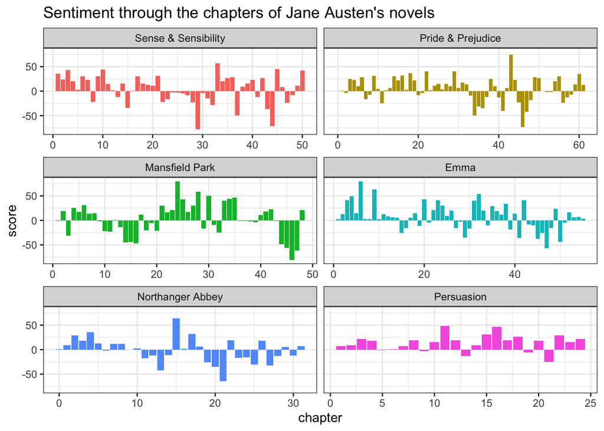

```r
ggplot(data = austen_sentiments,
       aes(x = chapter, y = score, fill = book)) +
  geom_col(show.legend = FALSE) +
  facet_wrap(~ book, ncol = 2, scales = "free_x") +
  theme_bw() +
  labs(title = "Sentiment through the chapters of Jane Austen's novels")
```

## 2.3 Sentiments through narrative

Another alternative to visualize the sentiment flow through the content of each book is to divide the text into “smaller” sections, as compared to chapters.

We count up how many positive and negative words there are in defined sections of each book. We define an `index` to keep track of where we are in the narrative; this index (using integer division) counts up sections of 80 lines of text.

Small sections of text may not have enough words in them to get a good estimate of sentiment, while really large sections can wash out narrative structure. For this example, using 80 lines works well, but this can vary depending on individual texts.

We then use `pivot_wider()` so that we have negative and positive sentiments in separate columns, and lastly calculate a net sentiment `(positive - negative)`

```r
austen_sentiments <- austen_tokens |>
  inner_join(sentiments, by = "word", relationship = "many-to-many") |>
  count(book, index = linenumber %/% 80, sentiment) |>
  pivot_wider(names_from = sentiment, values_from = n, values_fill = 0) |>
  mutate(score = positive - negative)

head(austen_sentiments, 10)
```

```
# A tibble: 10 × 5
   book                index negative positive score
   <fct>               <dbl>    <int>    <int> <int>
 1 Sense & Sensibility     0       16       26    10
 2 Sense & Sensibility     1       19       44    25
 3 Sense & Sensibility     2       12       23    11
 4 Sense & Sensibility     3       15       22     7
 5 Sense & Sensibility     4       16       29    13
 6 Sense & Sensibility     5       16       39    23
 7 Sense & Sensibility     6       24       37    13
 8 Sense & Sensibility     7       22       39    17
 9 Sense & Sensibility     8       30       35     5
10 Sense & Sensibility     9       14       18     4
```

Now we can plot these sentiment scores across the plot trajectory of each novel.

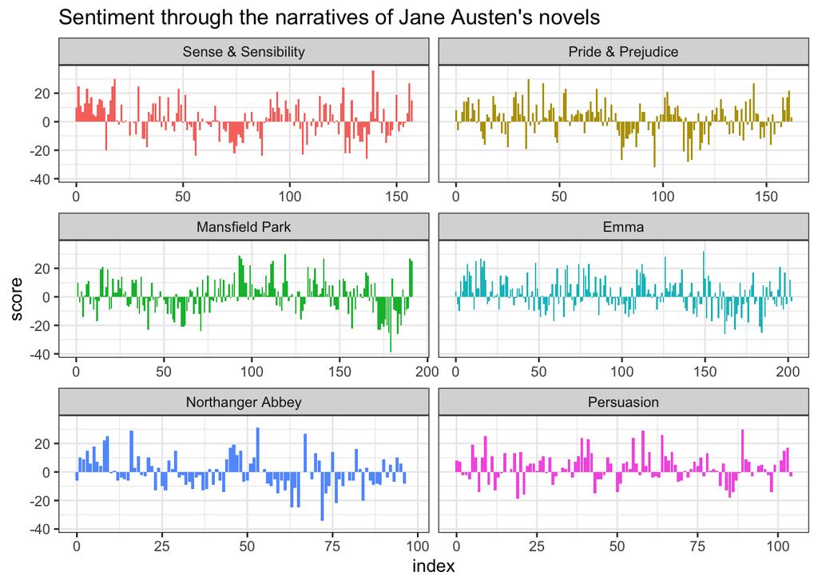

```r
ggplot(data = austen_sentiments,
       aes(x = index, y = score, fill = book)) +
  geom_col(show.legend = FALSE) +
  facet_wrap(~ book, ncol = 2, scales = "free_x") +
  theme_bw() +
  labs(title = "Sentiment through the narratives of Jane Austen's novels")
```

We can see how each novel begins with a fairly positive mood. Also, notice how each novel changes toward more positive or negative sentiment over the trajectory of the story.

Likewise, most novels tend to finish with a positive sentiment, perhaps with the exception of *Persuasion* that seems to end with a slightly negative score.